# 明日方舟同人创作分析报告

## 前言

这份数据分析报告目的是探究明日方舟同人创作作品，以同人二次创作的质量与玩家活跃度来分析该游戏自公测以来开放的游戏活动质量。

《明日方舟》是由鹰角网络开发的一款国产战略经营类游戏，于2019年5月1日公测。是TapTap游戏平台在2019年年度最佳游戏/最受玩家喜爱游戏/最具影响力国产游戏。 相比于其他手游，《明日方舟》的一大特点在于她是一款二次元手游，依靠二次元核心用户口碑宣传，二次创作吸引更多的玩家“入坑”游戏，B站则是玩家们二次创作发布的聚集地。

所以对B站《明日方舟》稿件的追踪与数据分析，以评判该手游的活动质量是有必要的。

B站的《明日方舟》相关的稿件有着更多的种类，游戏攻略，手书视频，同人音乐，背景考究等...

在游戏加入新元素（开启新副本，加入新的卡池）时会引起更多的二次创作， 优质的二次创作进而吸引更多的玩家，社区活跃度上升的除了能为游戏厂商带来更多的收益的同时，也给玩家带来更多元化的游戏体验。

所以，分析同人创作的活跃度可以是评价《明日方舟》活动好坏的一大指标。

这份报告对明日方舟开服一周年以来，B站质量最高的Top1000的稿件（以收藏量为标准）进行数据分析，对游戏中对各大活动时间线对应对投稿质量，以及玩家们关心对关键词进行分析，得出报告。

数据爬取&整理，数据分析报告 by shuzip

## 导入包与数据

```python
import pandas as pd
import numpy as np

import matplotlib.pyplot as plt
plt.rcParams["font.family"] = 'Arial Unicode MS'
%matplotlib inline
```

```python
'''
# Path of the file to read
filepath = "明日方舟哔哩哔哩top1000.csv"

# Read the file into a variable spotify_data
data = pd.read_csv(filepath, index_col="时间", parse_dates=True)
'''
```

```
'\n# Path of the file to read\nfilepath = "明日方舟哔哩哔哩top1000.csv"\n\n# Read the file into a variable spotify_data\ndata = pd.read_csv(filepath, index_col="时间", parse_dates=True)\n'
```

```python
# Path of the file to read
filepath = "明日方舟top1000稿件.csv"

# Read the file into a variable spotify_data
data = pd.read_csv(filepath, parse_dates=True)

# Path of the file to read
filepath2 = "明日方舟活动记录.csv"

# Read the file into a variable spotify_data
data2 = pd.read_csv(filepath2, parse_dates=True,header=None)
```

```python
data.head()
```

|  | 标题 | 标题_链接 | 图片 | 关键词 | 关键词1 | 数量 | 时间 | 名称_链接 | 名称 |
| --- | --- | --- | --- | --- | --- | --- | --- | --- | --- |
| 0 | 当她裙里拔枪那一刻！！世界：我赌你的枪里没有子弹！ | https://www.bilibili.com/video/BV1RJ41177XR?fr... | https://search.bilibili.com/all?keyword=%E6%98... | 02:41 | NaN | \n 1017.0万\n | \n 2020-01-16\n | https://space.bilibili.com/15377173?from=search | 烟季 |
| 1 | 【明日方舟】COSPLAY史上最大规模制作百人集结【萧影作品】 | https://www.bilibili.com/video/BV1iJ411W72i?fr... | https://search.bilibili.com/all?keyword=%E6%98... | 09:39 | 明日方舟 | \n 281.6万\n | \n 2019-12-25\n | https://space.bilibili.com/3949877?from=search | 萧影殿下 |
| 2 | b 站 热 度 年 度 总 结（禁止套娃）☆ | https://www.bilibili.com/video/BV1nJ411r7FQ?fr... | https://search.bilibili.com/all?keyword=%E6%98... | 05:17 | NaN | \n 544.9万\n | \n 2019-12-14\n | https://space.bilibili.com/415890389?from=search | 高坂大芥末 |
| 3 | 【本气黑猫】明日方舟攻略合集（更新危机合约 59区废墟 危机8 破碎大道 危机18 突袭 H... | https://www.bilibili.com/video/BV1p4411x7Ys?fr... | https://search.bilibili.com/all?keyword=%E6%98... | 21:56:51 | 明日方舟 | \n 2524.4万\n | \n 2019-05-02\n | https://space.bilibili.com/38829?from=search | 本气黑猫 |
| 4 | 明日方舟同人原创动画PV【晨昏交界】 | https://www.bilibili.com/video/BV1FJ411o7NA?fr... | https://search.bilibili.com/all?keyword=%E6%98... | 07:18 | 明日方舟 | \n 164.8万\n | \n 2019-11-24\n | https://space.bilibili.com/11928266?from=search | 本舔君 |

## 数据清洗

爬下来的数据是脏数据，所以需要对数据进行清洗，包括

- 去除空值
- 对列进行重名名
- 字符正则化匹配替换
- 数据类型转换

等操作

```python
data2 = data2.dropna(axis=0)
data2.head()
```

|  | 0 | 1 |
| --- | --- | --- |
| 0 | 2019年4月30日 | 公测开服活动 |
| 2 | 2019年5月23日 | 下载人数突破500万纪念活动 |
| 4 | 2019年5月30日 | 骑兵与猎人 |
| 6 | 2019年7月9日 | 主线“靶向药物”开启纪念限时活动（Part.1） |
| 8 | 2019年7月22日 | 主线“靶向药物”开启纪念限时活动（Part.2） |

```python
data.rename(columns={'名称':'up主', '数量':'播放量', '关键词':'视频时长'}, inplace = True)
```

```python
data.head()
```

|  | 标题 | 标题_链接 | 图片 | 视频时长 | 关键词1 | 播放量 | 时间 | 名称_链接 | up主 |
| --- | --- | --- | --- | --- | --- | --- | --- | --- | --- |
| 0 | 当她裙里拔枪那一刻！！世界：我赌你的枪里没有子弹！ | https://www.bilibili.com/video/BV1RJ41177XR?fr... | https://search.bilibili.com/all?keyword=%E6%98... | 02:41 | NaN | \n 1017.0万\n | \n 2020-01-16\n | https://space.bilibili.com/15377173?from=search | 烟季 |
| 1 | 【明日方舟】COSPLAY史上最大规模制作百人集结【萧影作品】 | https://www.bilibili.com/video/BV1iJ411W72i?fr... | https://search.bilibili.com/all?keyword=%E6%98... | 09:39 | 明日方舟 | \n 281.6万\n | \n 2019-12-25\n | https://space.bilibili.com/3949877?from=search | 萧影殿下 |
| 2 | b 站 热 度 年 度 总 结（禁止套娃）☆ | https://www.bilibili.com/video/BV1nJ411r7FQ?fr... | https://search.bilibili.com/all?keyword=%E6%98... | 05:17 | NaN | \n 544.9万\n | \n 2019-12-14\n | https://space.bilibili.com/415890389?from=search | 高坂大芥末 |
| 3 | 【本气黑猫】明日方舟攻略合集（更新危机合约 59区废墟 危机8 破碎大道 危机18 突袭 H... | https://www.bilibili.com/video/BV1p4411x7Ys?fr... | https://search.bilibili.com/all?keyword=%E6%98... | 21:56:51 | 明日方舟 | \n 2524.4万\n | \n 2019-05-02\n | https://space.bilibili.com/38829?from=search | 本气黑猫 |
| 4 | 明日方舟同人原创动画PV【晨昏交界】 | https://www.bilibili.com/video/BV1FJ411o7NA?fr... | https://search.bilibili.com/all?keyword=%E6%98... | 07:18 | 明日方舟 | \n 164.8万\n | \n 2019-11-24\n | https://space.bilibili.com/11928266?from=search | 本舔君 |

```python
to_replace = '\n'
value = ''
view_counts = data['播放量']

view_counts
```

```
0      \n        1017.0万\n
1       \n        281.6万\n
2       \n        544.9万\n
3      \n        2524.4万\n
4       \n        164.8万\n
                 ...
995     \n        137.8万\n
996      \n        23.6万\n
997      \n        76.0万\n
998      \n        37.4万\n
999       \n        9.8万\n
Name: 播放量, Length: 1000, dtype: object
```

```python
view_counts = view_counts.replace('\n', '',regex = True)
view_counts = view_counts.replace(' ', '',regex = True)
view_counts
```

```
0      1017.0万
1       281.6万
2       544.9万
3      2524.4万
4       164.8万
        ...
995     137.8万
996      23.6万
997      76.0万
998      37.4万
999       9.8万
Name: 播放量, Length: 1000, dtype: object
```

```python
view_counts.rename('播放量')
```

```
0      1017.0万
1       281.6万
2       544.9万
3      2524.4万
4       164.8万
        ...
995     137.8万
996      23.6万
997      76.0万
998      37.4万
999       9.8万
Name: 播放量, Length: 1000, dtype: object
```

```python
data = data.drop(['播放量'], axis=1)
data = data.drop(['名称_链接'], axis=1)
data
```

|  | 标题 | 标题_链接 | 图片 | 视频时长 | 关键词1 | 时间 | up主 |
| --- | --- | --- | --- | --- | --- | --- | --- |
| 0 | 当她裙里拔枪那一刻！！世界：我赌你的枪里没有子弹！ | https://www.bilibili.com/video/BV1RJ41177XR?fr... | https://search.bilibili.com/all?keyword=%E6%98... | 02:41 | NaN | \n 2020-01-16\n | 烟季 |
| 1 | 【明日方舟】COSPLAY史上最大规模制作百人集结【萧影作品】 | https://www.bilibili.com/video/BV1iJ411W72i?fr... | https://search.bilibili.com/all?keyword=%E6%98... | 09:39 | 明日方舟 | \n 2019-12-25\n | 萧影殿下 |
| 2 | b 站 热 度 年 度 总 结（禁止套娃）☆ | https://www.bilibili.com/video/BV1nJ411r7FQ?fr... | https://search.bilibili.com/all?keyword=%E6%98... | 05:17 | NaN | \n 2019-12-14\n | 高坂大芥末 |
| 3 | 【本气黑猫】明日方舟攻略合集（更新危机合约 59区废墟 危机8 破碎大道 危机18 突袭 H... | https://www.bilibili.com/video/BV1p4411x7Ys?fr... | https://search.bilibili.com/all?keyword=%E6%98... | 21:56:51 | 明日方舟 | \n 2019-05-02\n | 本气黑猫 |
| 4 | 明日方舟同人原创动画PV【晨昏交界】 | https://www.bilibili.com/video/BV1FJ411o7NA?fr... | https://search.bilibili.com/all?keyword=%E6%98... | 07:18 | 明日方舟 | \n 2019-11-24\n | 本舔君 |
| ... | ... | ... | ... | ... | ... | ... | ... |
| 995 | 《明日方舟》「骑兵与猎人」活动宣传PV | https://www.bilibili.com/video/BV1z4411p7D1?fr... | https://search.bilibili.com/all?keyword=%E6%98... | 01:19 | 明日方舟 | \n 2019-05-27\n | 明日方舟 |
| 996 | 【明日方舟沙雕】建议改成：危 机 合 约 | https://www.bilibili.com/video/BV1iJ41177Hg?fr... | https://search.bilibili.com/all?keyword=%E6%98... | 01:04 | 明日方舟 | \n 2020-01-16\n | sgai桫烙 |
| 997 | 【漫展】当一群博士遇到弑君者，迫害开始了...... | https://www.bilibili.com/video/BV1Wt411n7EU?fr... | https://search.bilibili.com/all?keyword=%E6%98... | 01:52 | NaN | \n 2019-07-20\n | 拔旗 |
| 998 | 【明日方舟】为什么大家说凯尔希是你前妻？ | https://www.bilibili.com/video/BV1DJ411574H?fr... | https://search.bilibili.com/all?keyword=%E6%98... | 08:51 | 明日方舟 | \n 2020-01-05\n | 杨颜同学 |
| 999 | 【明日方舟MMD】黑曜石节 特别放送（9位干员） | https://www.bilibili.com/video/BV1SE411r7SA?fr... | https://search.bilibili.com/all?keyword=%E6%98... | 02:38 | 明日方舟 | \n 2019-10-18\n | kinokoキノコ |

1000 rows × 7 columns

```python
data = pd.concat([data, view_counts], axis=1)
data
```

|  | 标题 | 标题_链接 | 图片 | 视频时长 | 关键词1 | 时间 | up主 | 播放量 |
| --- | --- | --- | --- | --- | --- | --- | --- | --- |
| 0 | 当她裙里拔枪那一刻！！世界：我赌你的枪里没有子弹！ | https://www.bilibili.com/video/BV1RJ41177XR?fr... | https://search.bilibili.com/all?keyword=%E6%98... | 02:41 | NaN | \n 2020-01-16\n | 烟季 | 1017.0万 |
| 1 | 【明日方舟】COSPLAY史上最大规模制作百人集结【萧影作品】 | https://www.bilibili.com/video/BV1iJ411W72i?fr... | https://search.bilibili.com/all?keyword=%E6%98... | 09:39 | 明日方舟 | \n 2019-12-25\n | 萧影殿下 | 281.6万 |
| 2 | b 站 热 度 年 度 总 结（禁止套娃）☆ | https://www.bilibili.com/video/BV1nJ411r7FQ?fr... | https://search.bilibili.com/all?keyword=%E6%98... | 05:17 | NaN | \n 2019-12-14\n | 高坂大芥末 | 544.9万 |
| 3 | 【本气黑猫】明日方舟攻略合集（更新危机合约 59区废墟 危机8 破碎大道 危机18 突袭 H... | https://www.bilibili.com/video/BV1p4411x7Ys?fr... | https://search.bilibili.com/all?keyword=%E6%98... | 21:56:51 | 明日方舟 | \n 2019-05-02\n | 本气黑猫 | 2524.4万 |
| 4 | 明日方舟同人原创动画PV【晨昏交界】 | https://www.bilibili.com/video/BV1FJ411o7NA?fr... | https://search.bilibili.com/all?keyword=%E6%98... | 07:18 | 明日方舟 | \n 2019-11-24\n | 本舔君 | 164.8万 |
| ... | ... | ... | ... | ... | ... | ... | ... | ... |
| 995 | 《明日方舟》「骑兵与猎人」活动宣传PV | https://www.bilibili.com/video/BV1z4411p7D1?fr... | https://search.bilibili.com/all?keyword=%E6%98... | 01:19 | 明日方舟 | \n 2019-05-27\n | 明日方舟 | 137.8万 |
| 996 | 【明日方舟沙雕】建议改成：危 机 合 约 | https://www.bilibili.com/video/BV1iJ41177Hg?fr... | https://search.bilibili.com/all?keyword=%E6%98... | 01:04 | 明日方舟 | \n 2020-01-16\n | sgai桫烙 | 23.6万 |
| 997 | 【漫展】当一群博士遇到弑君者，迫害开始了...... | https://www.bilibili.com/video/BV1Wt411n7EU?fr... | https://search.bilibili.com/all?keyword=%E6%98... | 01:52 | NaN | \n 2019-07-20\n | 拔旗 | 76.0万 |
| 998 | 【明日方舟】为什么大家说凯尔希是你前妻？ | https://www.bilibili.com/video/BV1DJ411574H?fr... | https://search.bilibili.com/all?keyword=%E6%98... | 08:51 | 明日方舟 | \n 2020-01-05\n | 杨颜同学 | 37.4万 |
| 999 | 【明日方舟MMD】黑曜石节 特别放送（9位干员） | https://www.bilibili.com/video/BV1SE411r7SA?fr... | https://search.bilibili.com/all?keyword=%E6%98... | 02:38 | 明日方舟 | \n 2019-10-18\n | kinokoキノコ | 9.8万 |

1000 rows × 8 columns

### 序列文本转时间格式

```python
time_list = data['时间']

time_list = time_list.replace('\n', '',regex = True)
time_list = time_list.replace(' ', '',regex = True)
time_list = time_list.replace('-', '',regex = True)
time_list
```

```
0      20200116
1      20191225
2      20191214
3      20190502
4      20191124
         ...
995    20190527
996    20200116
997    20190720
998    20200105
999    20191018
Name: 时间, Length: 1000, dtype: object
```

```python
time_data = pd.to_datetime(time_list,format='%Y-%m-%d')
time_data
```

```
0     2020-01-16
1     2019-12-25
2     2019-12-14
3     2019-05-02
4     2019-11-24
         ...
995   2019-05-27
996   2020-01-16
997   2019-07-20
998   2020-01-05
999   2019-10-18
Name: 时间, Length: 1000, dtype: datetime64[ns]
```

```python
data = data.drop(['时间'], axis=1)
data = pd.concat([data, time_data], axis=1)
data
```

|  | 标题 | 标题_链接 | 图片 | 视频时长 | 关键词1 | up主 | 播放量 | 时间 |
| --- | --- | --- | --- | --- | --- | --- | --- | --- |
| 0 | 当她裙里拔枪那一刻！！世界：我赌你的枪里没有子弹！ | https://www.bilibili.com/video/BV1RJ41177XR?fr... | https://search.bilibili.com/all?keyword=%E6%98... | 02:41 | NaN | 烟季 | 1017.0万 | 2020-01-16 |
| 1 | 【明日方舟】COSPLAY史上最大规模制作百人集结【萧影作品】 | https://www.bilibili.com/video/BV1iJ411W72i?fr... | https://search.bilibili.com/all?keyword=%E6%98... | 09:39 | 明日方舟 | 萧影殿下 | 281.6万 | 2019-12-25 |
| 2 | b 站 热 度 年 度 总 结（禁止套娃）☆ | https://www.bilibili.com/video/BV1nJ411r7FQ?fr... | https://search.bilibili.com/all?keyword=%E6%98... | 05:17 | NaN | 高坂大芥末 | 544.9万 | 2019-12-14 |
| 3 | 【本气黑猫】明日方舟攻略合集（更新危机合约 59区废墟 危机8 破碎大道 危机18 突袭 H... | https://www.bilibili.com/video/BV1p4411x7Ys?fr... | https://search.bilibili.com/all?keyword=%E6%98... | 21:56:51 | 明日方舟 | 本气黑猫 | 2524.4万 | 2019-05-02 |
| 4 | 明日方舟同人原创动画PV【晨昏交界】 | https://www.bilibili.com/video/BV1FJ411o7NA?fr... | https://search.bilibili.com/all?keyword=%E6%98... | 07:18 | 明日方舟 | 本舔君 | 164.8万 | 2019-11-24 |
| ... | ... | ... | ... | ... | ... | ... | ... | ... |
| 995 | 《明日方舟》「骑兵与猎人」活动宣传PV | https://www.bilibili.com/video/BV1z4411p7D1?fr... | https://search.bilibili.com/all?keyword=%E6%98... | 01:19 | 明日方舟 | 明日方舟 | 137.8万 | 2019-05-27 |
| 996 | 【明日方舟沙雕】建议改成：危 机 合 约 | https://www.bilibili.com/video/BV1iJ41177Hg?fr... | https://search.bilibili.com/all?keyword=%E6%98... | 01:04 | 明日方舟 | sgai桫烙 | 23.6万 | 2020-01-16 |
| 997 | 【漫展】当一群博士遇到弑君者，迫害开始了...... | https://www.bilibili.com/video/BV1Wt411n7EU?fr... | https://search.bilibili.com/all?keyword=%E6%98... | 01:52 | NaN | 拔旗 | 76.0万 | 2019-07-20 |
| 998 | 【明日方舟】为什么大家说凯尔希是你前妻？ | https://www.bilibili.com/video/BV1DJ411574H?fr... | https://search.bilibili.com/all?keyword=%E6%98... | 08:51 | 明日方舟 | 杨颜同学 | 37.4万 | 2020-01-05 |
| 999 | 【明日方舟MMD】黑曜石节 特别放送（9位干员） | https://www.bilibili.com/video/BV1SE411r7SA?fr... | https://search.bilibili.com/all?keyword=%E6%98... | 02:38 | 明日方舟 | kinokoキノコ | 9.8万 | 2019-10-18 |

1000 rows × 8 columns

```python
data.head()
```

|  | 标题 | 标题_链接 | 图片 | 视频时长 | 关键词1 | up主 | 播放量 | 时间 |
| --- | --- | --- | --- | --- | --- | --- | --- | --- |
| 0 | 当她裙里拔枪那一刻！！世界：我赌你的枪里没有子弹！ | https://www.bilibili.com/video/BV1RJ41177XR?fr... | https://search.bilibili.com/all?keyword=%E6%98... | 02:41 | NaN | 烟季 | 1017.0万 | 2020-01-16 |
| 1 | 【明日方舟】COSPLAY史上最大规模制作百人集结【萧影作品】 | https://www.bilibili.com/video/BV1iJ411W72i?fr... | https://search.bilibili.com/all?keyword=%E6%98... | 09:39 | 明日方舟 | 萧影殿下 | 281.6万 | 2019-12-25 |
| 2 | b 站 热 度 年 度 总 结（禁止套娃）☆ | https://www.bilibili.com/video/BV1nJ411r7FQ?fr... | https://search.bilibili.com/all?keyword=%E6%98... | 05:17 | NaN | 高坂大芥末 | 544.9万 | 2019-12-14 |
| 3 | 【本气黑猫】明日方舟攻略合集（更新危机合约 59区废墟 危机8 破碎大道 危机18 突袭 H... | https://www.bilibili.com/video/BV1p4411x7Ys?fr... | https://search.bilibili.com/all?keyword=%E6%98... | 21:56:51 | 明日方舟 | 本气黑猫 | 2524.4万 | 2019-05-02 |
| 4 | 明日方舟同人原创动画PV【晨昏交界】 | https://www.bilibili.com/video/BV1FJ411o7NA?fr... | https://search.bilibili.com/all?keyword=%E6%98... | 07:18 | 明日方舟 | 本舔君 | 164.8万 | 2019-11-24 |

## 分析统计

对明日方舟开发的活动时间进行分箱统计

### 明日方舟活动一览

2019年04月30日10:00 公测开服活动

2019年05月23日04:00 下载人数突破500万纪念活动

2019年05月30日10:00 骑兵与猎人

2019年07月09日16:00 主线“靶向药物”开启纪念限时活动（Part.1）

2019年07月22日04:00 主线“靶向药物”开启纪念限时活动（Part.2）

2019年08月15日04:00 SideStory「火蓝之心」黑曜石节

2019年08月27日16:00 SideStory「火蓝之心」

2019年10月01日04:00 金秋

2019年10月15日16:00 微型故事集「战地秘闻」

2019年11月01日04:00 感谢庆典

2019年11月04日 明日方舟×肯德基合作活动

2019年11月19日16:00 SideStory「喧闹法则」

2019年11月19日16:00 危机合约/2019

2019年12月11日04:00 新章节“局部坏死”预热活动

2019年12月24日16:00 主线【局部坏死】

2020年01月01日00:00 跨年纪念

2020年01月09日04:00 洪炉示岁

2020年01月16日16:00 限定寻访【地生五金】

2020年02月25日16:00 微型故事「午间逸话」

2020年03月03日04:00 「万类共生」联合公益活动

2020年03月17日16:00 危机合约新赛季「荒芜行动」

2020年04月06日04:00 春季限时日常

```python
20190430
20190523
20190530
20190709
20190815
20191001
20191015
20191101
20191119
20191211
20200109
20200225
20200317
```

```
20200317
```

```python
t1 = pd.datetime(2019,4,30)
t2 = pd.datetime(2019,5,30)
t3 = pd.datetime(2019,7,9)
t4 = pd.datetime(2019,8,15)
t5 = pd.datetime(2019,10,1)
t6 = pd.datetime(2019,10,15)
t7 = pd.datetime(2019,11,19)
t8 = pd.datetime(2019,12,11)
t9 = pd.datetime(2020,1,9)
t10 = pd.datetime(2020,2,25)
t11 = pd.datetime(2020,3,17)
```

```python
data.sort_values(by = '时间',ascending = True)
```

|  | 标题 | 标题_链接 | 图片 | 视频时长 | 关键词1 | up主 | 播放量 | 时间 |
| --- | --- | --- | --- | --- | --- | --- | --- | --- |
| 85 | 《明日方舟》游戏概念宣传PV | https://www.bilibili.com/video/BV1ux41147Eh?fr... | https://search.bilibili.com/all?keyword=%E6%98... | 03:04 | 明日方舟 | 明日方舟 | 510.2万 | 2017-09-08 |
| 529 | 1979年引进苏联的明日方舟 | https://www.bilibili.com/video/BV1us411T7Md?fr... | https://search.bilibili.com/all?keyword=%E6%98... | 02:04 | 明日方舟 | PackTTT | 85.7万 | 2018-08-12 |
| 568 | 《明日方舟》游戏概念宣传PV-bilibili | https://www.bilibili.com/video/BV1Ub41127ch?fr... | https://search.bilibili.com/all?keyword=%E6%98... | 03:01 | 明日方舟 | 明日方舟 | 88.3万 | 2019-02-15 |
| 843 | 《明日方舟》声优影像资料-企鹅物流 | https://www.bilibili.com/video/BV1Mb411H74e?fr... | https://search.bilibili.com/all?keyword=%E6%98... | 01:37 | 明日方舟 | 明日方舟 | 68.1万 | 2019-03-14 |
| 514 | 【明日方舟】游戏背景音乐合集 共63曲 内含下载地址 已更新危机合约(4P) | https://www.bilibili.com/video/BV15b411u7iZ?fr... | https://search.bilibili.com/all?keyword=%E6%98... | 04:01:57 | 明日方舟 | 叫我诺瓦露sama | 34.4万 | 2019-04-07 |
| ... | ... | ... | ... | ... | ... | ... | ... | ... |
| 552 | 【明日方舟】赫默家的龙女仆 | https://www.bilibili.com/video/BV1jK411L7y3?fr... | https://search.bilibili.com/all?keyword=%E6%98... | 01:38 | 明日方舟 | -SHL- | 27.3万 | 2020-04-05 |
| 344 | 【明日方舟动画】危机合约-破碎大道（上） | https://www.bilibili.com/video/BV1rC4y1s7Bc?fr... | https://search.bilibili.com/all?keyword=%E6%98... | 02:19 | 明日方舟 | -TKirsa- | 24.0万 | 2020-04-06 |
| 405 | 【明日方舟/手书】明日清晨 | https://www.bilibili.com/video/BV1it4y1U7FK?fr... | https://search.bilibili.com/all?keyword=%E6%98... | 02:05 | 明日方舟 | 放肆的流星 | 17.2万 | 2020-04-08 |
| 205 | 【明日方舟/手书】A story about her dreams【安洁莉娜】 | https://www.bilibili.com/video/BV1cz411b7M1?fr... | https://search.bilibili.com/all?keyword=%E6%98... | 02:37 | 明日方舟 | 音無口罩中间商 | 25.1万 | 2020-04-10 |
| 950 | 我发现斯卡蒂睡衣直播间的那天 | https://www.bilibili.com/video/BV1hk4y197Zy?fr... | https://search.bilibili.com/all?keyword=%E6%98... | 02:41 | NaN | 扶桑大红花丶 | 17.8万 | 2020-04-11 |

1000 rows × 8 columns

```python
k0 = 0
k1 = 0
t1=pd.datetime(2019,4,30)
t2=pd.datetime(2019,5,30)
num_list = []
index_list = []
for i in data['时间']:
    if i <=t1:
        k0 = k0 +1
num_list.append(k0)
index_list.append('\n~'+str(t1).replace(" 00:00:00", ""))
for i in data['时间']:
    if i > t1 and i <t2:
        k1 = k1 +1
num_list.append(k1)
index_list.append(str(t1).replace(" 00:00:00", " ")+'\n~\n'+str(t2).replace(" 00:00:00", ""))
print(k1)
print(index_list)
```

```
104
['\n~2019-04-30', '2019-04-30 \n~\n2019-05-30']
```

```python
k2 = 0
for i in data['时间']:
    if i > t2 and i <=t3:
        k2 = k2 +1
num_list.append(k2)
index_list.append(str(t2).replace(" 00:00:00", "")+'\n~\n'+str(t3).replace(" 00:00:00", ""))

k3 = 0
for i in data['时间']:
    if i > t3 and i <=t4:
        k3 = k3 +1
num_list.append(k3)
index_list.append(str(t3).replace(" 00:00:00", "")+'\n~\n'+str(t4).replace(" 00:00:00", ""))

k4 = 0
for i in data['时间']:
    if i > t4 and i <=t5:
        k4 = k4 +1
num_list.append(k4)
index_list.append(str(t4).replace(" 00:00:00", "")+'\n~\n'+str(t5).replace(" 00:00:00", ""))

k5 = 0
for i in data['时间']:
    if i > t5 and i <=t6:
        k5 = k5 +1
num_list.append(k5)
index_list.append(str(t5).replace(" 00:00:00", "") +'\n~\n'+str(t6).replace(" 00:00:00", ""))

k6 = 0
for i in data['时间']:
    if i > t6 and i <=t7:
        k6 = k6 +1
num_list.append(k6)
index_list.append(str(t6).replace(" 00:00:00", "")+'\n~\n'+str(t7).replace(" 00:00:00", ""))

k7 = 0
for i in data['时间']:
    if i > t7 and i <=t8:
        k7 = k7 +1
num_list.append(k7)
index_list.append(str(t7).replace(" 00:00:00", "")+'\n~\n'+str(t8).replace(" 00:00:00", ""))

k8 = 0
for i in data['时间']:
    if i > t8 and i <=t9:
        k8 = k8 +1
num_list.append(k8)
index_list.append(str(t8).replace(" 00:00:00", "")+'\n~\n'+str(t9).replace(" 00:00:00", ""))

k9 = 0
for i in data['时间']:
    if i > t9 and i <=t10:
        k9 = k9 +1
num_list.append(k9)
index_list.append(str(t9).replace(" 00:00:00", "")+'\n~\n'+str(t10).replace(" 00:00:00", ""))

k10 = 0
for i in data['时间']:
    if i > t10 and i <=t11:
        k10 = k10 +1
num_list.append(k10)
index_list.append(str(t10).replace(" 00:00:00", "")+'\n~\n'+str(t11).replace(" 00:00:00", ""))

k11 = 0
for i in data['时间']:
    if i > t11:
        k11 = k11 +1

num_list.append(k11)
index_list.append(str(t11).replace(" 00:00:00", "")+'\n~\n')
```

各大活动时间的所产生大高质量稿件统计

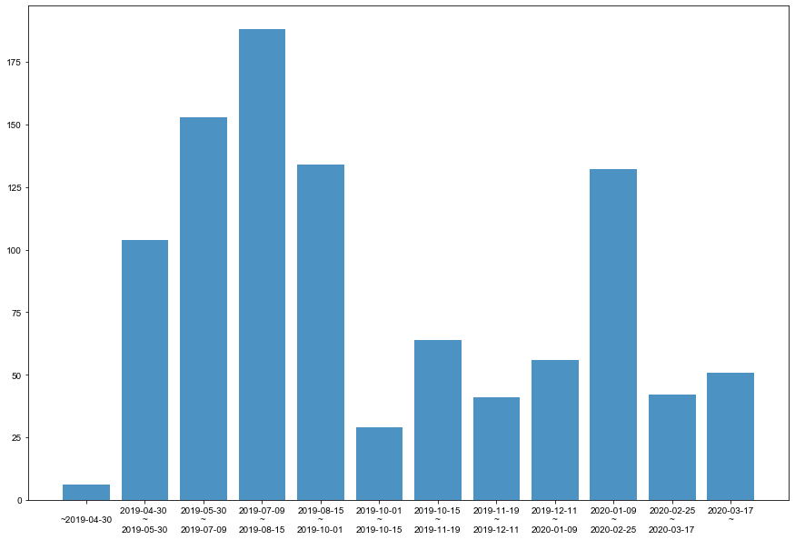

```python
index = np.arange(12)
values = [5,6,7,8,9]
std = [0.8,1,0.4,0.9,1.3]



plt.figure(figsize=(15, 10))
plt.bar(index,  # 指定类别
        num_list,  # 指定数量值
        error_kw={'ecolor':'0.1',  # 指定误差线的颜色
                  'capsize':6  # 指定误差线两头横线的宽度
                 },
        alpha=0.8,  # 指定条头图的透明度，值的范围是0~1
        label='例一', # 指定图便的名称

       )
plt.xticks(index,index_list )

plt.show()
```

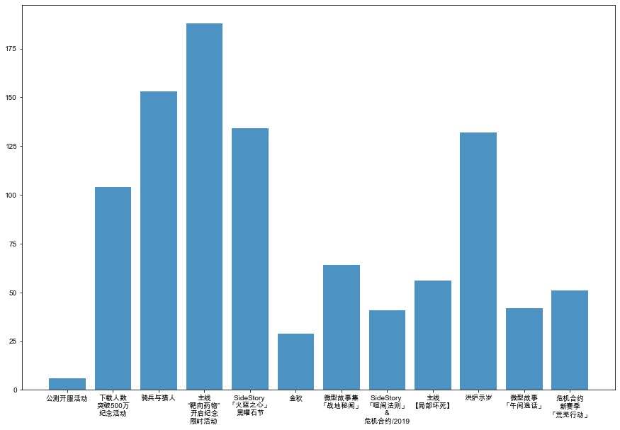

```python
index = np.arange(12)


plt.figure(figsize=(15, 10))
plt.bar(index,  # 指定类别
        num_list,  # 指定数量值
        error_kw={'ecolor':'0.1',  # 指定误差线的颜色
                  'capsize':6  # 指定误差线两头横线的宽度
                 },
        alpha=0.8,  # 指定条头图的透明度，值的范围是0~1
        label='例一', # 指定图便的名称

       )
plt.xticks(index,['公测开服活动','下载人数\n突破500万\n纪念活动','骑兵与猎人','主线\n“靶向药物”\n开启纪念\n限时活动',
                  'SideStory \n「火蓝之心」\n黑曜石节','金秋','微型故事集\n「战地秘闻」','SideStory \n「喧闹法则」\n&\n危机合约/2019','主线\n【局部坏死】',
                 '洪炉示岁','微型故事\n「午间逸话」','危机合约\n新赛季\n「荒芜行动」'
                 ] )

plt.show()
```

## 标题关键词

标题关键词是稿件吸引玩家观看二次创作的一大要素，对于通过分析top1000的稿件标题文本，我们可以更好的理解玩家更为关心哪方面的内容。

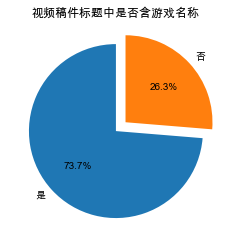

```python
labels = ['是','否']
sizes = [1000-data['关键词1'].isnull().sum(),data['关键词1'].isnull().sum()]
explode = (0,0.15)
plt.pie(sizes,explode=explode,labels=labels,autopct='%1.1f%%',shadow=False,startangle=90)
plt.title("视频稿件标题中是否含游戏名称")
plt.show()
```

（可以发现B站的推荐算法很强，在top1000的稿件中，有四分之一以上的高质量稿件在标题没有明日方舟的情况下，依然能精准推送给游戏玩家群体）

```python
# 导入扩展库
import re # 正则表达式库
import collections # 词频统计库
import numpy as np # numpy数据处理库
import jieba # 结巴分词
import wordcloud # 词云展示库
from PIL import Image # 图像处理库
import matplotlib.pyplot as plt # 图像展示库

word_list = []
for i in data['标题']:
    word_list.append(i)

string_data = str(word_list)

# 文本预处理
pattern = re.compile(u'\t|\n|\.|-|:|;|\)|\(|\?|"') # 定义正则表达式匹配模式
string_data = re.sub(pattern, '', string_data) # 将符合模式的字符去除

# 文本分词
seg_list_exact = jieba.cut(string_data, cut_all = False) # 精确模式分词
object_list = []
remove_words = [u'【', u'】', u' ', u',', u'！', u'，', u'（', u'）', u'/', u'？', u'的', u'了', u'你', u'的'
               , u'《', u'》', u'：', u'—', u'是', u'!', u"'",
               ] # 自定义去除词库


for word in seg_list_exact: # 循环读出每个分词
    if word not in remove_words: # 如果不在去除词库中
        object_list.append(word) # 分词追加到列表

# 词频统计
word_counts = collections.Counter(object_list) # 对分词做词频统计
word_counts_top20 = word_counts.most_common(20) # 获取前10最高频的词
print (word_counts_top20) # 输出检查
```

```
Building prefix dict from the default dictionary ...
Loading model from cache /var/folders/56/dvwjw6sd287f3sqcnmd7qllr0000gn/T/jieba.cache
Loading model cost 0.683 seconds.
Prefix dict has been built successfully.
```

```
[('方舟', 767), ('明日', 743), ('手书', 122), ('干员', 109), ('博士', 79), ('我', 76), ('罗德岛', 69), ('动画', 62), ('沙雕', 60), ('龙门', 52), ('危机', 45), ('攻略', 44), ('人', 43), ('向', 40), ('在', 40), ('日常', 37), ('当', 35), ('合约', 33), ('刀客', 33), ('陈', 33)]
```

```python
name_list = []
num_list2 = []
for i in word_counts_top20:
    name_list.append(i[0])
    num_list2.append(i[1])

print(name_list)
print(num_list2)
```

```
['方舟', '明日', '手书', '干员', '博士', '我', '罗德岛', '动画', '沙雕', '龙门', '危机', '攻略', '人', '向', '在', '日常', '当', '合约', '刀客', '陈']
[767, 743, 122, 109, 79, 76, 69, 62, 60, 52, 45, 44, 43, 40, 40, 37, 35, 33, 33, 33]
```

标题出现率最高的词组TOP20

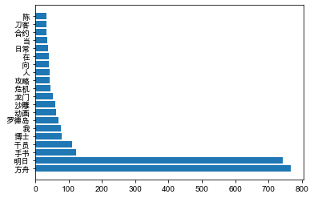

```python
N = 20
x = num_list2
y = name_list

# 绘图 x= 起始位置， bottom= 水平条的底部(左侧), y轴， height 水平条的宽度， width 水平条的长度
p1 = plt.bar(x=0, bottom=y, height=0.8, width=x, orientation="horizontal")
plt.figure(figsize=(20, 15))
# 展示图形
plt.show()
```

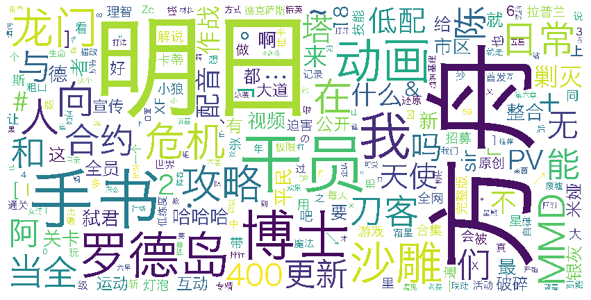

```python
# 词频展示
#mask = np.array(Image.open('background.jpg')) # 定义词频背景
wc = wordcloud.WordCloud(
    background_color='white', # 设置背景颜色
    font_path='/System/Library/Fonts/Hiragino Sans GB.ttc', # 设置字体格式
     # 设置背景图
    max_words=250, # 最多显示词数
    max_font_size=80 , # 字体最大值
    scale=64  # 调整图片清晰度，值越大越清楚
)

wc.generate_from_frequencies(word_counts) # 从字典生成词云
#image_colors = wordcloud.ImageColorGenerator(mask) # 从背景图建立颜色方案
#wc.recolor(color_func=image_colors) # 将词云颜色设置为背景图方案
wc.to_file("temp.jpg") # 将图片输出为文件

plt.figure(figsize=(15, 10))
plt.imshow(wc) # 显示词云
plt.axis('off') # 关闭坐标轴
plt.show() # 显示图像
```

对于标题而言，除了“明日方舟”，“博士”，“阿米娅”，”罗德岛“，”龙门“,"理智"这些游戏内的角色、地名及专有名次外

明日方舟的二次创作稿件比较倾向于手书、配音，动画，解说，攻略等

值得一提的是有一位up主的名字也登上了冠词之中，可见该up主在明日方舟的二次创作视频的质量及数量之高。

## 结果及可提共的建议

从上述图表分析来看，在激发高质量二次创作稿件这一衡量纬度上，明日方舟最成功的任务是2019年07月09日开始的主线“靶向药物”开启纪念限时活动

[figure not shown]

同时，2019年05月30日的 骑兵与猎人与同年08月15日的 SideStory「火蓝之心」黑曜石节也有这不错的反响

[figure not shown]

在2020年上半年里，明日方舟最为成功的活动为 洪炉示岁。

[figure not shown]

后续的活动可以总结上述成功的案例继续策划进行。

在词频统计方面，动画、手术、MMD是一大二次创作的热门，目前，明日方舟已经多次在B站上举办视频创作大赛，但此类比赛是任何稿件都可以参与都项目 在未来，也许可以在手书、动画、MMD上单独设置赛道，举办特别的比赛。